# Project 1 Predictive Modeling

# Introduction

During this project, we will analyse two data sets in order to obtain more insights about them and predict some objective variable. First, we will approach the problem with a Linear Regression model, then, with the second data set, we will try to model a Generalised Linear Model. These are the data sets used:

- Airbnb: https://www.kaggle.com/datasets/dipeshkhemani/airbnb-cleaned-europe-dataset
- Data scientist jobs: https://www.kaggle.com/datasets/nikhilbhathi/data-scientist-salary-us-glassdoor

# Linear Regression

## Data preparation

For the first part of the assignment we will be using the Airbnb data set. It consist of information about the Airbnb stays in some European cities. The variables are the following:

- City: Amsterdam, Athens, Barcelona, Berlin, Budapest, Lisbon, Paris, Rome or Vienna
- Price: continuous numeric variable
- Day: WeekDay or Weekend
- Room Type: Entire home/apt, Private room or Shared room
- Shared Room: binary variable
- Private Room: binary variable
- Person capacity: integer from 2 to 6.
- Superhost: binary variable
- Multiple Rooms: binary variable
- Business: binary variable
- Cleanliness Rating: integer from 2 to 10.
- Guest satisfaction: continuous numeric variable
- Bedrooms: integer from 0 to 10
- City center(km): continuous numeric variable
- Metro distance(km): continuous numeric variable
- Attraction index: continuous variable measuring the attraction to the Airbnb by the costumers
- Normalised Atraction index: same but normalised
- Restraunt Index: continuous variable measuring the restaurant performance index
- Normalised Restraunt Index: same but normalised

The goal would be to predict the Price variable in terms of the others. First, it is always a good idea to separate from the beginning the training set (what the tool is going to see) from the testing set (used only to validate predictions)

```r
library(tidyverse)
```

[output not shown]

```r
library(MASS)
```

[output not shown]

```r
library(caret) #ML tools
```

[output not shown]

```r
library(e1071)
```

[output not shown]

[output not shown]

```r
par(mar = c(2, 2, 2, 2))
```

[output not shown]

```r
# Loading and preparing data
```

[output not shown]

```r
Airbnb <- read.csv("Airbnb_data.csv")
```

[output not shown]

```r
Airbnb
```

| City | Price | Day | Room.Type | Shared.Room | Private.Room | Person.Capacity | Superhost | Multiple.Rooms | Business | Cleanliness.Rating | Guest.Satisfaction | Bedrooms | City.Center..km. | Metro.Distance..km. | Attraction.Index | Normalised.Attraction.Index | Restraunt.Index | Normalised.Restraunt.Index |
| --- | --- | --- | --- | --- | --- | --- | --- | --- | --- | --- | --- | --- | --- | --- | --- | --- | --- | --- |
| Amsterdam | 194.0337 | Weekday | Private room | False | True | 2 | False | 1 | 0 | 10 | 93 | 1 | 5.0229638 | 2.53938000 | 78.69038 | 4.166708 | 98.25390 | 6.846473 |
| Amsterdam | 344.2458 | Weekday | Private room | False | True | 4 | False | 0 | 0 | 8 | 85 | 1 | 0.4883893 | 0.23940392 | 631.17638 | 33.421209 | 837.28076 | 58.342928 |
| Amsterdam | 264.1014 | Weekday | Private room | False | True | 2 | False | 0 | 1 | 9 | 87 | 1 | 5.7483119 | 3.65162129 | 75.27588 | 3.985908 | 95.38695 | 6.646700 |
| Amsterdam | 433.5294 | Weekday | Private room | False | True | 4 | False | 0 | 1 | 9 | 90 | 2 | 0.3848620 | 0.43987608 | 493.27253 | 26.119108 | 875.03310 | 60.973565 |
| Amsterdam | 485.5529 | Weekday | Private room | False | True | 2 | True | 0 | 0 | 10 | 98 | 1 | 0.5447382 | 0.31869265 | 552.83032 | 29.272733 | 815.30574 | 56.811677 |
| Amsterdam | 552.8086 | Weekday | Private room | False | True | 3 | False | 0 | 0 | 8 | 100 | 2 | 2.1314201 | 1.90466824 | 174.78896 | 9.255191 | 225.20166 | 15.692376 |
| Amsterdam | 215.1243 | Weekday | Private room | False | True | 2 | False | 0 | 0 | 10 | 94 | 1 | 1.8810916 | 0.72974674 | 200.16765 | 10.599010 | 242.76552 | 16.916251 |
| Amsterdam | 2771.3074 | Weekday | Entire home/apt | False | False | 4 | True | 0 | 0 | 10 | 100 | 3 | 1.6868070 | 1.45840357 | 208.80811 | 11.056528 | 272.31382 | 18.975219 |
| Amsterdam | 1001.8044 | Weekday | Entire home/apt | False | False | 4 | False | 0 | 0 | 9 | 96 | 2 | 3.7191414 | 1.19611235 | 106.22646 | 5.624761 | 133.87620 | 9.328686 |
| Amsterdam | 276.5215 | Weekday | Private room | False | True | 2 | False | 1 | 0 | 10 | 88 | 1 | 3.1423614 | 0.92440444 | 206.25286 | 10.921226 | 238.29126 | 16.604478 |

[output cut: 990 more lines]

[output not shown]

```r
# split between training and testing sets
```

[output not shown]

```r
spl = createDataPartition(Airbnb$Price, p = 0.8, list = FALSE)  # 80% for training
```

[output not shown]

```r
AirbnbTrain = Airbnb[spl,]
```

[output not shown]

```r
AirbnbTest = Airbnb[-spl,]
```

[output not shown]

```r
str(AirbnbTrain)
```

```
'data.frame':   33373 obs. of  19 variables:
 $ City                       : chr  "Amsterdam" "Amsterdam" "Amsterdam" "Amsterdam" ...
 $ Price                      : num  194 344 434 486 553 ...
 $ Day                        : chr  "Weekday" "Weekday" "Weekday" "Weekday" ...
 $ Room.Type                  : chr  "Private room" "Private room" "Private room" "Private room" ...
 $ Shared.Room                : chr  "False" "False" "False" "False" ...
 $ Private.Room               : chr  "True" "True" "True" "True" ...
 $ Person.Capacity            : num  2 4 4 2 3 4 2 4 2 2 ...
 $ Superhost                  : chr  "False" "False" "False" "True" ...
 $ Multiple.Rooms             : int  1 0 0 0 0 0 0 0 0 1 ...
 $ Business                   : int  0 0 1 0 0 0 0 0 0 0 ...
 $ Cleanliness.Rating         : num  10 8 9 10 8 10 10 8 10 8 ...
 $ Guest.Satisfaction         : num  93 85 90 98 100 100 96 87 100 96 ...
 $ Bedrooms                   : int  1 1 2 1 2 3 1 1 1 1 ...
 $ City.Center..km.           : num  5.023 0.488 0.385 0.545 2.131 ...
 $ Metro.Distance..km.        : num  2.539 0.239 0.44 0.319 1.905 ...
 $ Attraction.Index           : num  78.7 631.2 493.3 552.8 174.8 ...
 $ Normalised.Attraction.Index: num  4.17 33.42 26.12 29.27 9.26 ...
 $ Restraunt.Index            : num  98.3 837.3 875 815.3 225.2 ...
 $ Normalised.Restraunt.Index : num  6.85 58.34 60.97 56.81 15.69 ...
```

[output not shown]

Once separated, let’s clean and understand the training set. First, we check any missing values. There is any missing value.

```r
any(is.na(AirbnbTrain))
```

```
[1] FALSE
```

[output not shown]

Now we evaluate the numerical variables, having some statistics such as minnimum, maximum, quantiles mean and median.

```r
summary(AirbnbTrain)
```

```
     City               Price              Day
 Length:33373       Min.   :   34.78   Length:33373
 Class :character   1st Qu.:  144.02   Class :character
 Mode  :character   Median :  203.82   Mode  :character
                    Mean   :  259.59
                    3rd Qu.:  297.37
                    Max.   :16445.62
  Room.Type         Shared.Room        Private.Room
 Length:33373       Length:33373       Length:33373
 Class :character   Class :character   Class :character
 Mode  :character   Mode  :character   Mode  :character



 Person.Capacity  Superhost         Multiple.Rooms
 Min.   :2.000   Length:33373       Min.   :0.0000
 1st Qu.:2.000   Class :character   1st Qu.:0.0000
 Median :3.000   Mode  :character   Median :0.0000
 Mean   :3.231                      Mean   :0.2944
 3rd Qu.:4.000                      3rd Qu.:1.0000
 Max.   :6.000                      Max.   :1.0000
    Business      Cleanliness.Rating Guest.Satisfaction
 Min.   :0.0000   Min.   : 2.00      Min.   : 20.0
 1st Qu.:0.0000   1st Qu.: 9.00      1st Qu.: 90.0
 Median :0.0000   Median :10.00      Median : 95.0
 Mean   :0.3404   Mean   : 9.44      Mean   : 93.1
 3rd Qu.:1.0000   3rd Qu.:10.00      3rd Qu.: 98.0
 Max.   :1.0000   Max.   :10.00      Max.   :100.0
    Bedrooms      City.Center..km.   Metro.Distance..km.
 Min.   : 0.000   Min.   : 0.01504   Min.   : 0.002301
 1st Qu.: 1.000   1st Qu.: 1.28225   1st Qu.: 0.237157
 Median : 1.000   Median : 2.25636   Median : 0.392208
 Mean   : 1.165   Mean   : 2.68557   Mean   : 0.606579
 3rd Qu.: 1.000   3rd Qu.: 3.58948   3rd Qu.: 0.682632
 Max.   :10.000   Max.   :25.28456   Max.   :14.273577
 Attraction.Index  Normalised.Attraction.Index
 Min.   :  15.15   Min.   :  0.9263
 1st Qu.: 124.38   1st Qu.:  5.5370
 Median : 228.42   Median :  9.9713
 Mean   : 293.33   Mean   : 11.7206
 3rd Qu.: 393.09   3rd Qu.: 15.4899
 Max.   :4512.60   Max.   :100.0000
 Restraunt.Index   Normalised.Restraunt.Index
 Min.   :  19.58   Min.   :  0.6407
 1st Qu.: 210.99   1st Qu.: 11.1699
 Median : 516.51   Median : 21.8160
 Mean   : 624.76   Mean   : 25.5180
 3rd Qu.: 859.43   3rd Qu.: 36.6838
 Max.   :6696.16   Max.   :100.0000
```

[output not shown]

From the data obtained we can obtain the following insigths:

##### Price

The maximum of price seems to be too large for the mean and median. We can get a better look with a boxplot:

[output not shown]

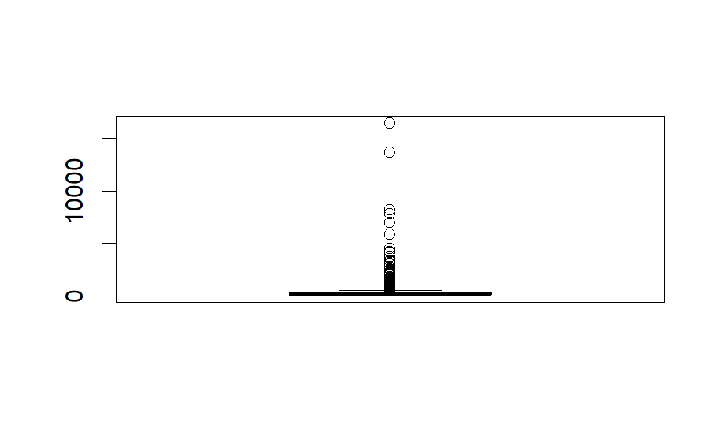

```r
boxplot(AirbnbTrain$Price)
```

Although the maximum is an outlier, it is not alone, as we can observe many other outliers that could be representing expensive Airbnb. In the case the maximum would be alone, we could get rid of it, but in this case this can be meaningful data.

##### Attraction.Index and Restraunt.Index

As we have the normalize columns, we have redundant information, so we will only keep those.

```r
AirbnbTrain <- subset(AirbnbTrain, select = -c(Attraction.Index, Restraunt.Index ))
```

[output not shown]

The rest of numerical variables seem fine with their ranges, so no changes are needed. Let’s now evaluate the categorical variables:

```r
table(AirbnbTrain$City)
```

```
Amsterdam    Athens Barcelona    Berlin  Budapest
     1672      4222      2254      2018      3212
   Lisbon     Paris      Rome    Vienna
     4602      5377      7181      2835
```

[output not shown]

```r
table(AirbnbTrain$Day)
```

```
Weekday Weekend
  16692   16681
```

[output not shown]

```r
table(AirbnbTrain$Room.Type)
```

```
Entire home/apt    Private room     Shared room
          22583           10541             249
```

[output not shown]

```r
table(AirbnbTrain$Shared.Room)
```

```
False  True
33124   249
```

[output not shown]

```r
table(AirbnbTrain$Private.Room)
```

```
False  True
22832 10541
```

[output not shown]

```r
table(AirbnbTrain$Superhost)
```

```
False  True
24039  9334
```

[output not shown]

```r
table(AirbnbTrain$Multiple.Rooms)
```

```
    0     1
23547  9826
```

[output not shown]

```r
table(AirbnbTrain$Business)
```

```
    0     1
22013 11360
```

[output not shown]

The variable Room type has the same information than Private Room and Shared room, so we will erase the last two.

```r
AirbnbTrain <- subset(AirbnbTrain, select = -c(Private.Room, Shared.Room ))
```

[output not shown]

Finally, the variable Superhost is as False/True, we will code as binary the False/True options.

```r
AirbnbTrain$Superhost<-as.numeric(as.logical(AirbnbTrain$Superhost))
```

[output not shown]

## Explanatory analysis

In order to better comprehend our data, we need to plot it. Concretely, we will have in mind plots respect to the objective variable, the price, for trying to visualize a model for predicting it.

[output not shown]

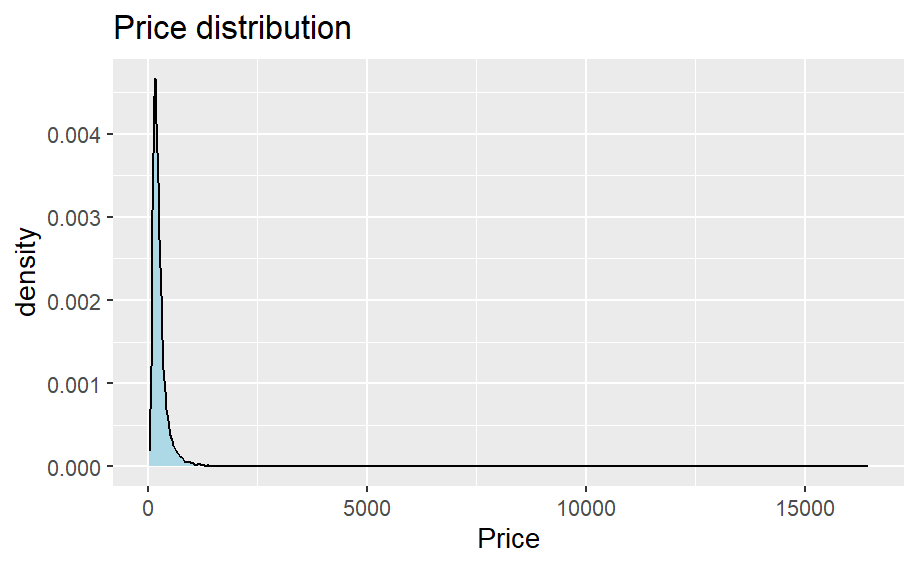

```r
ggplot(AirbnbTrain, aes(Price)) + geom_density(fill="lightblue") + xlab("Price") + ggtitle("Price distribution")
```

```r
## from the statistics obtained before we know price has no 0 values as minimum is 34, so we can apply the logarithm to better visualize it
```

[output not shown]

[output not shown]

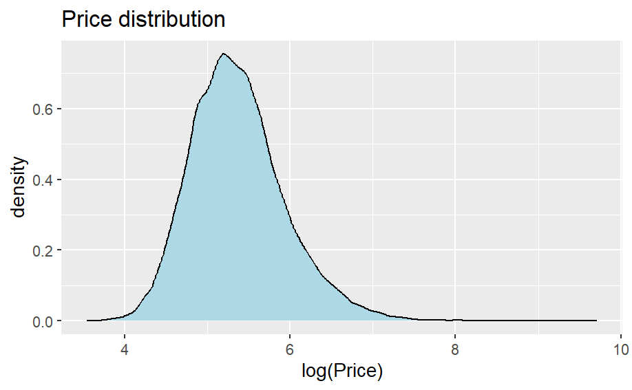

```r
ggplot(AirbnbTrain, aes(log(Price))) + geom_density(fill="lightblue") + xlab("log(Price)") + ggtitle("Price distribution")
```

```r
mean(log(AirbnbTrain$Price))
```

```
[1] 5.36695
```

[output not shown]

```r
exp(mean(log(AirbnbTrain$Price)))
```

```
[1] 214.2086
```

[output not shown]

After observing the response variable alone, we can approximate some regressions with plots. We now have in mind the Prices in terms of the city, in order to better understand the data.

[output not shown]

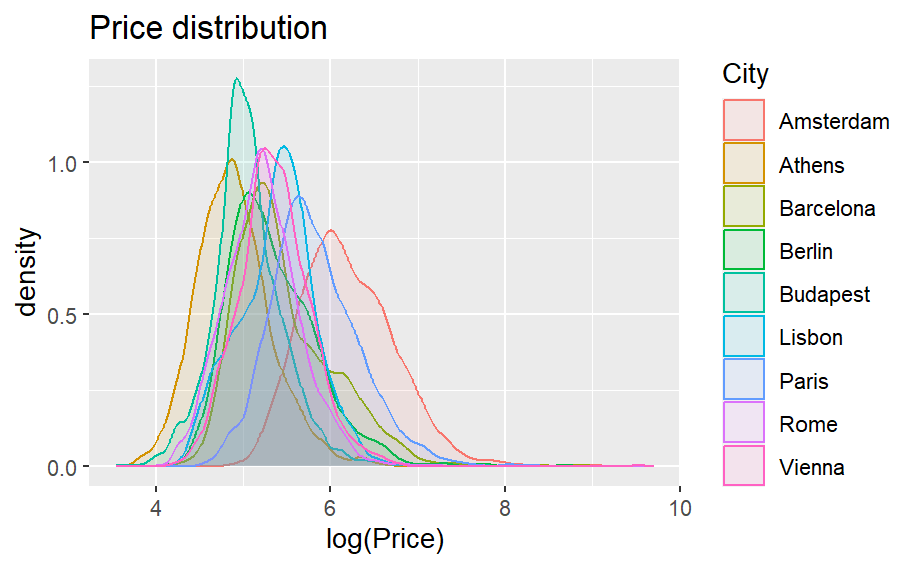

```r
ggplot(AirbnbTrain, aes(log(Price))) + geom_density(aes(group=City, colour=City, fill=City), alpha=0.1) + ggtitle("Price distribution")
```

Some of the variables that we may think are important to determine the price of an Airbnb are: distance to metro, distance to city center, number of bedrooms, restaurant and atraction indexes. Let’s observe them.

[output not shown]

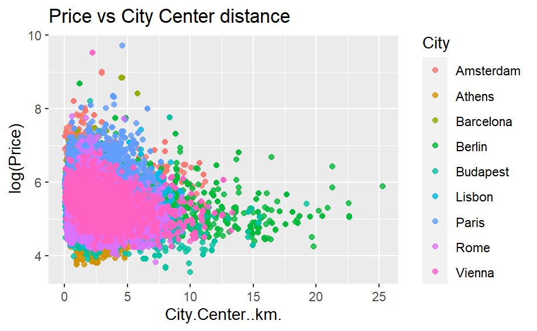

```r
ggplot(AirbnbTrain, aes(x=City.Center..km., y=log(Price), color=City)) + geom_point(alpha=0.8) + ggtitle("Price vs City Center distance")
```

[output not shown]

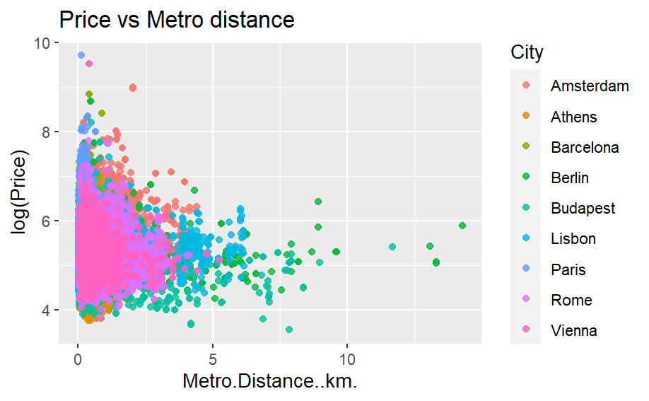

```r
ggplot(AirbnbTrain, aes(x=Metro.Distance..km., y=log(Price), color=City)) + geom_point(alpha=0.8) + ggtitle("Price vs Metro distance")
```

As observed, the most expensive Airbnb are the ones really close to the metro and center (there are no points at the rigth upper corner).

```r
ggplot(AirbnbTrain, aes(x = Bedrooms, y = log(Price), fill = City)) +
```

[output not shown]

```r
  geom_bar(stat = "identity", position = "dodge", alpha = 0.8) +
```

[output not shown]

[output not shown]

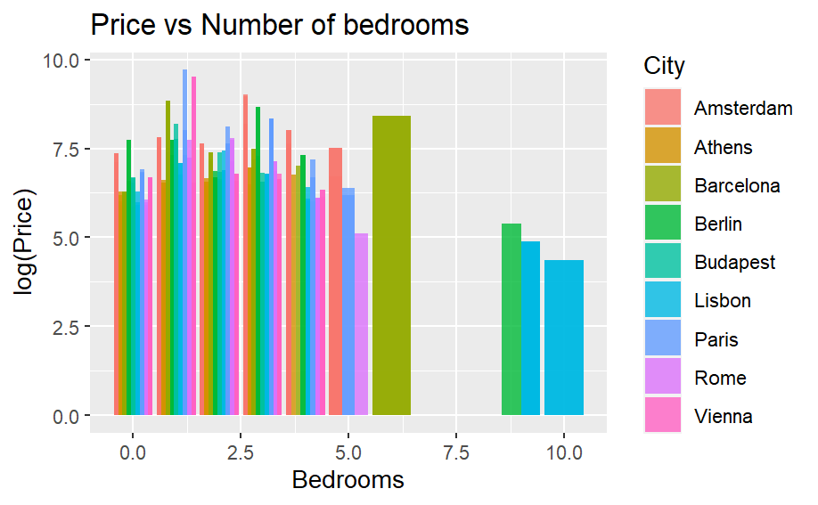

```r
  ggtitle("Price vs Number of bedrooms")
```

```r
table(AirbnbTrain$Bedrooms)
```

```
    0     1     2     3     4     5     6     9    10
 2992 23107  6204   999    52     6     2     9     2
```

[output not shown]

[output not shown]

[figure not shown]

```r
ggplot(AirbnbTrain, aes(x=Normalised.Attraction.Index, y=log(Price), color=City)) + geom_point(alpha=0.8) + ggtitle("Price vs Attraction Index")
```

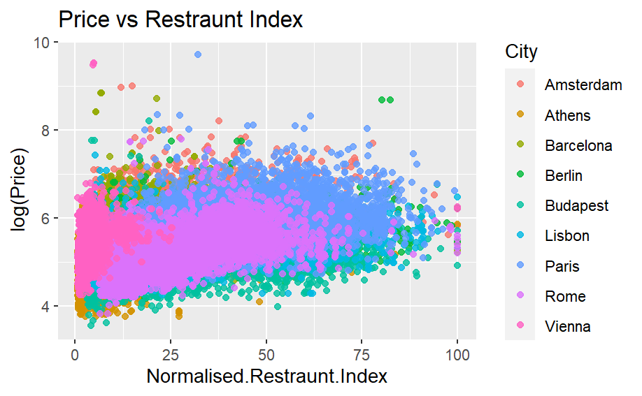

```r
ggplot(AirbnbTrain, aes(x=Normalised.Restraunt.Index, y=log(Price), color=City)) + geom_point(alpha=0.8) + ggtitle("Price vs Restraunt Index")
```

Finally, the indexes did not provide as much information. But, focusing on the Restaurant index we could visualize a kind of linear tendency with lower prices on the ones with lower index and higher prices close to higher index rating. However, is still difficult to make assumptions without an appropiate model. In the following sections this relationship would be better explained.

### Correlations

The most important term when evaluating a data set for predictions are the correlations. Which are the variables that are more correlated with our objective variable? First, we would focus on isolated correlations:

```r
## Moving the objective function to the last position
AirbnbTrain<-AirbnbTrain[, c(1:(2 - 1), (2 + 1):ncol(AirbnbTrain), 2)]
```

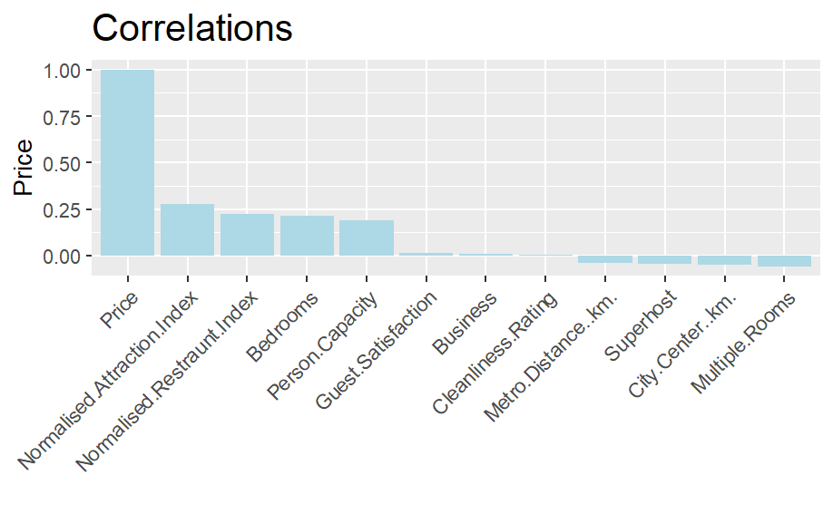

```r
corr_delay <- sort(cor(AirbnbTrain[,c(4:15)])["Price",], decreasing = T)
corr=data.frame(corr_delay)
ggplot(corr,aes(x = row.names(corr), y = corr_delay)) +
  geom_bar(stat = "identity", fill = "lightblue") +
  scale_x_discrete(limits= row.names(corr)) +
  labs(x = "", y = "Price", title = "Correlations") +
  theme(plot.title = element_text(hjust = 0, size = rel(1.5)),
        axis.text.x = element_text(angle = 45, hjust = 1))
```

A priori, the only variables helpful for performing a linear regression predictor are Normalised Atraction Index, Normalised Restraunt Index, number of Bedrooms and Person Capacity. However, is important to recall that we are plotting the individual correlations, maybe if we add information between variables we could get higher correlations, and therefore have better predictions.

### Simple linear regression: interpreting the betas

Before developing a complex model for prediction, we will try to create a simpler one where we avoid colinearities and better understand the betas. Therefore, we first create a simple linear regressor with the higher correlation variable: Normalised Atraction Index.

```r
simple_linFit <- lm(log(Price) ~ Normalised.Attraction.Index, data=AirbnbTrain)
summary(simple_linFit)
```

```
Call:
lm(formula = log(Price) ~ Normalised.Attraction.Index, data = AirbnbTrain)

Residuals:
    Min      1Q  Median      3Q     Max
-2.5502 -0.3501 -0.0402  0.2917  4.3110

Coefficients:
                             Estimate Std. Error
(Intercept)                 5.0139014  0.0048153
Normalised.Attraction.Index 0.0301482  0.0003345
                            t value Pr(>|t|)
(Intercept)                 1041.25   <2e-16 ***
Normalised.Attraction.Index   90.12   <2e-16 ***
---
Signif. codes:
0 ‘***’ 0.001 ‘**’ 0.01 ‘*’ 0.05 ‘.’ 0.1 ‘ ’ 1

Residual standard error: 0.5125 on 33371 degrees of freedom
Multiple R-squared:  0.1957,    Adjusted R-squared:  0.1957
F-statistic:  8121 on 1 and 33371 DF,  p-value: < 2.2e-16
```

The simple linear regression model is defined as: $log(Price) = \beta_0 + \beta_1 N.Attraction.Index= 5.01 + 0.03 N.Attraction.Index$

where $\beta_1$ explains that a 1 unit increase in the normalized attraction index would increase in 0.03 % the log of the Price. We can trust this model because the information gain is larger than the noise, as the p_value close to 0 confirms.

Furthermore, focusing on the global information, the residual standard error, although is larger than the local, is still not that high. The residual standard error is higher than the local because there is not much information gain from the model, however, we can trust the model as the information that $\beta_1$ gives us has small standard error.

Finally, the $R^2$ tell us about the information gain we get from the model. Almost 20%, while the remaining 80% is noise. In general, this is a difficult application, as the most correlated variable is only giving us 20% of the information, so it would be difficult to obtain high $R^2$ values on the test set. However, we always need to compare with a benchmark for better conclusions (on the following sections).

To better comprehend how this model approaches the price prediction we will plot the regression line:

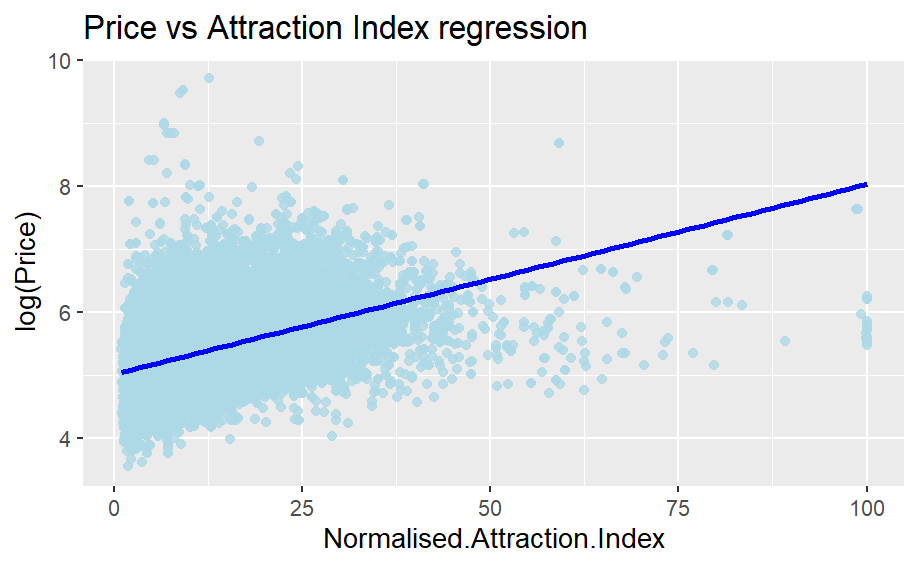

```r
# Scatter plot

ggplot(AirbnbTrain, aes(x = Normalised.Attraction.Index, y = log(Price))) +
  geom_point(alpha = 0.8, color= 'lightblue') +
  geom_smooth(method = "lm", se = FALSE, color = "blue") +
  ggtitle("Price vs Attraction Index regression")
```

After understanding the model, let’s evaluate how it predicts (this result will be later compared with the benchmark and the complex linear regression model).

```r
pred_simple= exp(predict(simple_linFit, newdata= AirbnbTest))

#Let's know validate the predictions, calculating R^2 in the testing set

R2_simple= cor(pred_simple, log(AirbnbTest$Price))^2
R2_simple
```

```
[1] 0.107618
```

As expected, $R^2$ on the testing set is smaller than on the training set (remember it was 0.2). Always is more difficult to predict future values than present ones.

Finally, we can perform some diagnosis of our simple model to obtain more conclusions:

- Residuals vs Fitted Values: this plot show as how our model is not homoscedastic, that is, the variance of the residuals is not constant with the Price, but it increases (negatively) for higher prices. This can be explained by the non symmetric distribution and the outliers.
- Q-Q Residuals: the residuals are not normally distributed, as the outliers in the tails of the plot suggest issues with extreme residuals.
- Scale-Location Plot: again this plots confirm us our model is not homocedastic, as there is a clear deviation on the line.

In general, we can say our model is not good for our objective.

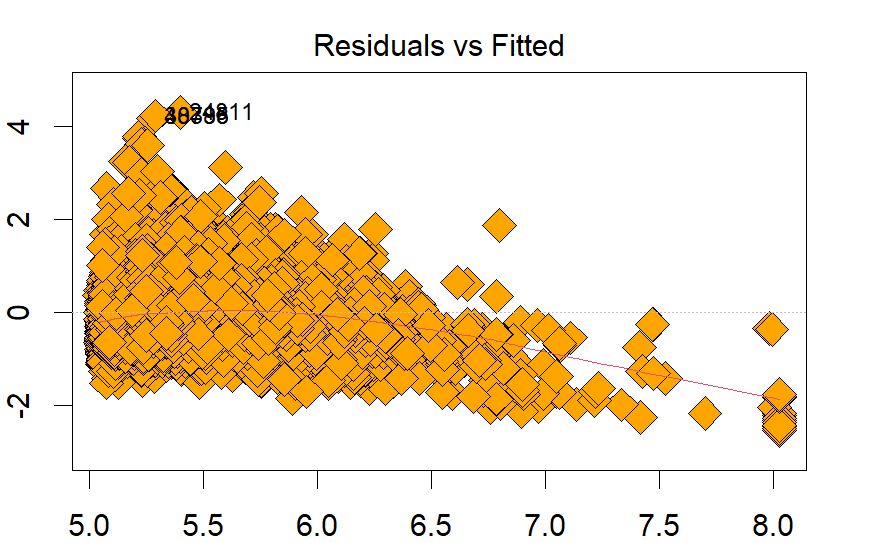

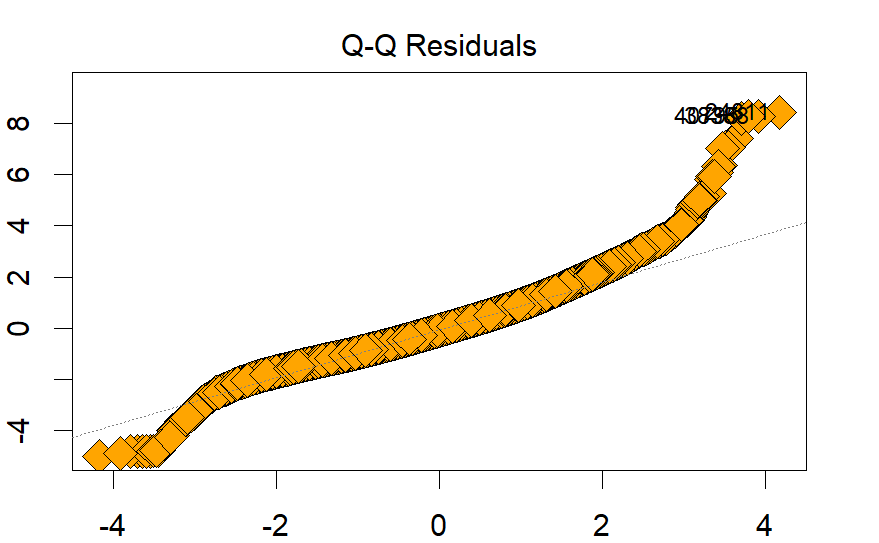

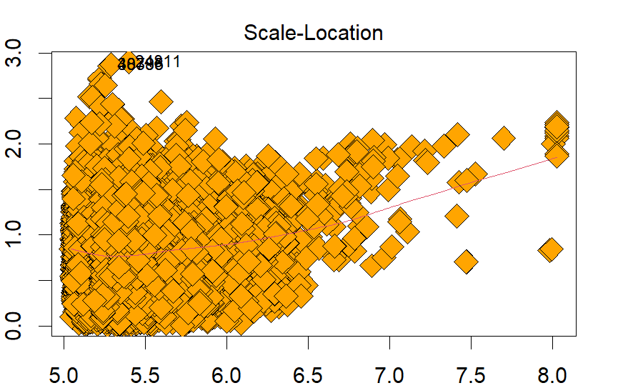

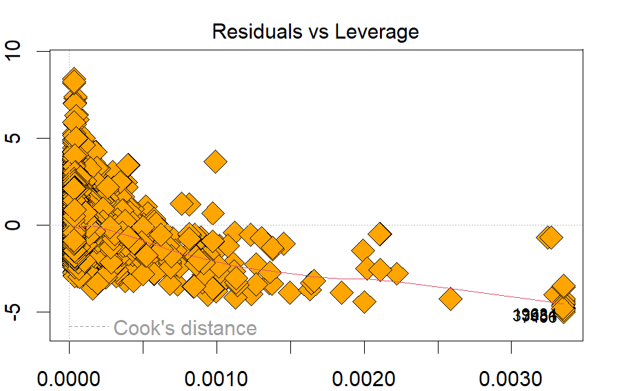

```r
par(mar = c(2, 2, 2, 2))

plot(simple_linFit, pch=23 ,bg='orange',cex=2)
```

## Predictive analysis

After understanding better how our data is constructed and being defined a simple regression model, we will know try to develop the best model for prediction. But first, we need to define the benchmark, from where we have to improve.

### Benchmark

In our case, as we are dealing with numerical continuous target, we would consider the benchmark as predicting the mean (again using the logarithmic transformation). This would be similar to the following model: $log(price)= \beta_0 \times 1$

```r
benchFit <- lm(log(Price) ~ 1, data=AirbnbTrain)
pred_bench <- exp(predict(benchFit, newdata=AirbnbTest))
```

As on the mean predictor the $R^2$ can not be computed, we will use the Mean Squared Error for comparison:

```r
#MSE comparison: my model vs benchmark
MSE_simple=sqrt(mean((pred_simple - log(AirbnbTest$Price))^2))
MSE_bench= sqrt(mean((pred_bench - log(AirbnbTest$Price))^2))
MSE_simple
```

```
[1] 236.6051
```

```r
MSE_bench
```

```
[1] 208.7679
```

Clearly, our simple model is worse than the naive model, so we need to improve it.

### Complex model (without interactions)

As a first approach to find our perfect model, we would fit a model with all the variables we have. To do it, we first must change the format of the variable ‘Superhost’ on the test set for non finding programmatical errors when calculating the predictions.

```r
AirbnbTest$Superhost<-as.numeric(as.logical(AirbnbTest$Superhost))
```

```r
all_linFit <- lm(log(Price) ~ ., data=AirbnbTrain)

# Predict on the test set
pred_all <- exp(predict(all_linFit, newdata = AirbnbTest))

  # Calculate MSE
MSE_all <- sqrt(mean((pred_all - AirbnbTest$Price)^2))
R2_all= cor(pred_all, AirbnbTest$Price)^2
summary(all_linFit)
```

```
Call:
lm(formula = log(Price) ~ ., data = AirbnbTrain)

Residuals:
    Min      1Q  Median      3Q     Max
-1.7040 -0.2135 -0.0341  0.1747  4.6469

Coefficients:
                              Estimate Std. Error
(Intercept)                  5.1680842  0.0265432
CityAthens                  -1.3932647  0.0109075
CityBarcelona               -0.5848560  0.0113928
CityBerlin                  -0.7650703  0.0121096
CityBudapest                -1.3280244  0.0106865
CityLisbon                  -0.8694512  0.0104234
CityParis                   -0.4900109  0.0104536
CityRome                    -1.0107936  0.0094722
CityVienna                  -0.8059918  0.0112969
DayWeekend                   0.0341489  0.0036849
Room.TypePrivate room       -0.3429637  0.0050365
Room.TypeShared room        -0.8355665  0.0215541
Person.Capacity              0.0890971  0.0019913
Superhost                    0.0205942  0.0043794
Multiple.Rooms               0.0422474  0.0047220
Business                     0.1255528  0.0047872
Cleanliness.Rating           0.0349950  0.0028817
Guest.Satisfaction           0.0013828  0.0003190
Bedrooms                     0.1366027  0.0035868
City.Center..km.            -0.0109172  0.0014492
Metro.Distance..km.          0.0137130  0.0031683
Normalised.Attraction.Index  0.0118635  0.0003722
Normalised.Restraunt.Index   0.0033531  0.0001935
                             t value Pr(>|t|)
(Intercept)                  194.705  < 2e-16 ***
CityAthens                  -127.735  < 2e-16 ***
CityBarcelona                -51.336  < 2e-16 ***
CityBerlin                   -63.179  < 2e-16 ***
CityBudapest                -124.272  < 2e-16 ***
CityLisbon                   -83.414  < 2e-16 ***
CityParis                    -46.875  < 2e-16 ***
```

[output cut: 8 more lines]

```
Business                      26.227  < 2e-16 ***
Cleanliness.Rating            12.144  < 2e-16 ***
Guest.Satisfaction             4.335 1.46e-05 ***
Bedrooms                      38.085  < 2e-16 ***
City.Center..km.              -7.533 5.08e-14 ***
Metro.Distance..km.            4.328 1.51e-05 ***
Normalised.Attraction.Index   31.871  < 2e-16 ***
Normalised.Restraunt.Index    17.331  < 2e-16 ***
---
Signif. codes:
0 ‘***’ 0.001 ‘**’ 0.01 ‘*’ 0.05 ‘.’ 0.1 ‘ ’ 1

Residual standard error: 0.3346 on 33350 degrees of freedom
Multiple R-squared:  0.6573,    Adjusted R-squared:  0.6571
F-statistic:  2908 on 22 and 33350 DF,  p-value: < 2.2e-16
```

```r
R2_all
```

```
[1] 0.2571013
```

```r
MSE_all
```

```
[1] 256.9851
```

In order to try to improve this metrics, now we need to take into account interactions between variables.

### Complex model (with interactions)

We first start by doing some feature selection, as does not have any sense to add all the features because we will be adding more noise. Therefore, we would try to find the best combination of the most correlated variables: Normalised.Attraction.Index, Normalised.Restraunt.Index, Bedrooms and Person.Capacity.In order to do it, we will focus on both the $R^2$ and the MSE, trying to find the model that best maximizes the first one while minimazing the second one.

```r
Y <- log(AirbnbTrain$Price)

variables_to_add= list("Normalised.Attraction.Index", "Normalised.Restraunt.Index", "Bedrooms", "Person.Capacity")

#variables_to_add= list( "Bedrooms", "Person.Capacity", "Normalised.Attraction.Index", "Normalised.Restraunt.Index")

#variables_to_add= list("Bedrooms", "Normalised.Attraction.Index", "Normalised.Restraunt.Index",  "Person.Capacity")

#variables_to_add= list("Person.Capacity", "Normalised.Attraction.Index", "Normalised.Restraunt.Index", "Bedrooms" )

# Create an empty data frame to store models and MSE
mse_df <- data.frame(MSE = numeric(length(variables_to_add)), R2= numeric(length(variables_to_add)), Variables = character(length(variables_to_add)), stringsAsFactors = FALSE)

models <- list()

# Fit models and calculate MSE
for (i in seq_along(variables_to_add)) {
  formula <- as.formula(paste("Y ~ ", paste(variables_to_add[1:i], collapse = " + ")))
  model <- lm(formula, data = AirbnbTrain)

  # Store the model
  models[[i]] <- model

  # Predict on the test set
  pred <- exp(predict(model, newdata = AirbnbTest))

  # Calculate MSE
  mse <- sqrt(mean((pred - log(AirbnbTest$Price))^2))

  R2= cor(pred, log(AirbnbTest$Price))^2

  # Store MSE and variables in the data frame
  mse_df[i, "MSE"] <- mse
  mse_df[i, "R2"] <- R2
  mse_df[i, "Variables"] <- paste(variables_to_add[1:i], collapse = ", ")
}

# Find the model with the lowest MSE
best_model_index <- which.min(mse_df$MSE)
best_model <- models[[best_model_index]]

# Print results
cat("Best model includes variables:", mse_df$Variables[best_model_index], "\n")
```

```
Best model includes variables: Normalised.Attraction.Index, Normalised.Restraunt.Index
```

```r
cat("MSE of the best model:", mse_df$MSE[best_model_index], "\n")
```

```
MSE of the best model: 230.3861
```

```r
cat("R2 of the best model:", mse_df$R2[best_model_index], "\n")
```

```
R2 of the best model: 0.1686613
```

```r
mse_df
```

| MSE | R2 | Variables |
| --- | --- | --- |
| 236.6051 | 0.1076180 | Normalised.Attraction.Index |
| 230.3861 | 0.1686613 | Normalised.Attraction.Index, Normalised.Restraunt.Index |
| 238.4329 | 0.2440631 | Normalised.Attraction.Index, Normalised.Restraunt.Index, Bedrooms |
| 240.2886 | 0.2717147 | Normalised.Attraction.Index, Normalised.Restraunt.Index, Bedrooms, Person.Capacity |

```r
NA
```

After trying several combinations, we lead to the conclusion that, althought adding the Bedrooms and Person.Capacity variables may increase the R2, meaning is adding information, it also adds noise as the MSE increases a lot. By the MSE the best model is the one with only the first two variables (the ones more correlated), but we will choose to add also Bedrooms so $R^2$ is bigger enougth.

Now, let’s try to add interactions with the categorical variables. After trying several combinations, we lead to the conclusion that City was the most informative variable in order to interact with the indexes. Later, we add Bedrooms and tried several more interactions, however, any improvement was achieved. Finally, the best model we could fit was the following:

```r
best_linFit <- lm(log(Price) ~ City*(Normalised.Attraction.Index + Normalised.Restraunt.Index)^2 + sqrt(Bedrooms) , data=AirbnbTrain)

# Predict on the test set
pred_best <- exp(predict(best_linFit, newdata = AirbnbTest))

  # Calculate MSE
MSE_best <- sqrt(mean((pred_best - log(AirbnbTest$Price))^2))
R2_best= cor(pred, log(AirbnbTest$Price))^2
R2_best
```

```
[1] 0.2717147
```

```r
MSE_best
```

```
[1] 254.6664
```

For better conclusions we can perform some diagnosis. Contrary to the simple model, this one has achieved to be more homocedastic, having constant variance of the residuals and better distribution in general.

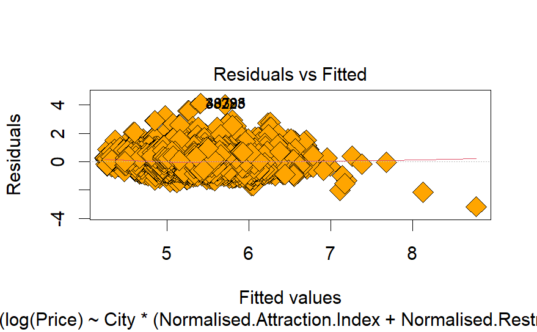

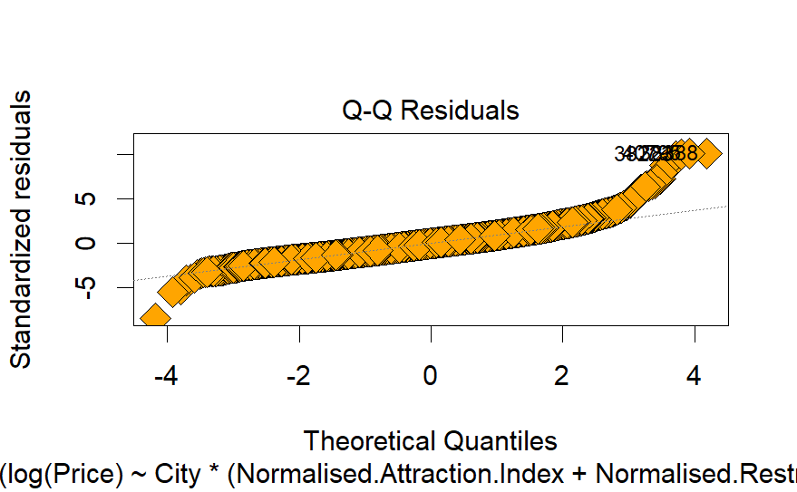

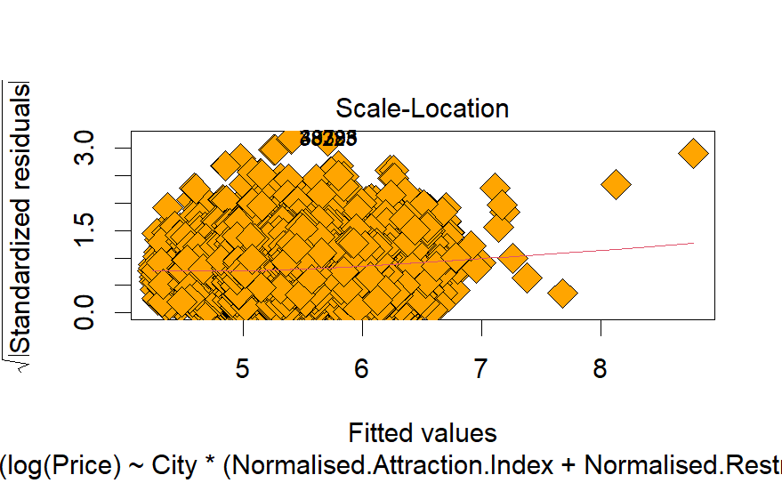

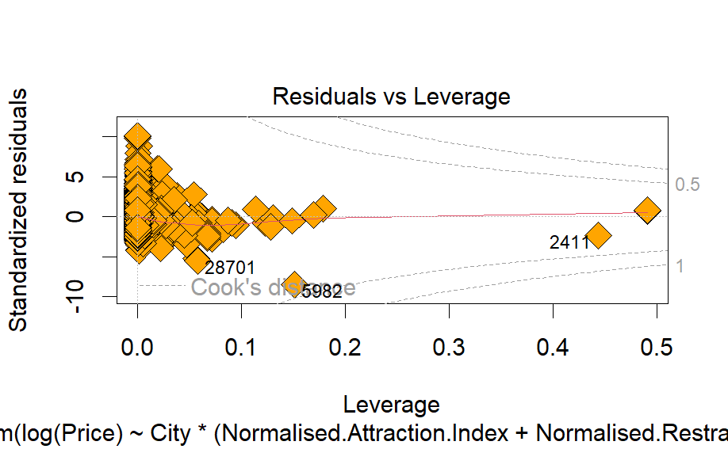

```r
plot(best_linFit, pch=23 ,bg='orange',cex=2)
```

### Prediction Intervals

Finally, we would evaluate the predictions of our model with the prediction intervals.

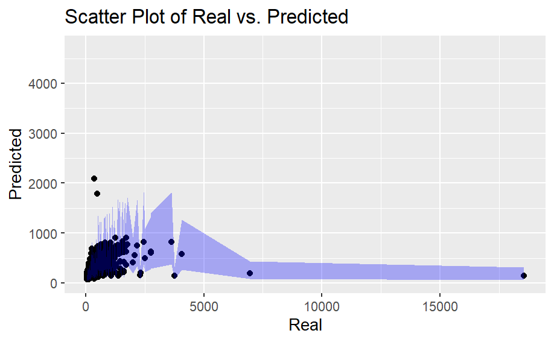

```r
pred_best <- predict(best_linFit, newdata = AirbnbTest, interval='prediction')

y = AirbnbTest$Price
yhat = exp(pred_best)

# Assuming pred.log contains the lower and upper prediction intervals
AirbnbTest$Pred = exp(pred_best[, "fit"])
AirbnbTest$Real = y
AirbnbTest$Lower = exp(pred_best[, "lwr"])
AirbnbTest$Upper = exp(pred_best[, "upr"])

# Create a data frame for plotting
plot_data <- data.frame(Real = AirbnbTest$Real,
                        Pred = AirbnbTest$Pred,
                        Lower = AirbnbTest$Lower,
                        Upper = AirbnbTest$Upper)
# Prediction Interval Plot
ggplot(plot_data, aes(x = Real, y = Pred)) +
  geom_point() +
  geom_ribbon(aes(ymin = Lower, ymax = Upper), alpha = 0.3, fill = "blue") +
  labs(title = "Scatter Plot of Real vs. Predicted",
       x = "Real",
       y = "Predicted")
```

As we can observe, most of the points lies inside the shadow of the prediction intervals. To better evaluate the exact quantity we can count them.

```r
# Counting the points outside the intervals
outside_interval_count <- sum(AirbnbTest$Real < AirbnbTest$Lower | AirbnbTest$Real > AirbnbTest$Upper)

# Calculating the coverage
total_points <- nrow(AirbnbTest)
coverage <- round(100-(outside_interval_count / total_points) * 100, digits=1)

# Printing the coverage
print(paste("Percentage of points inside the intervals:", coverage, "%"))
```

```
[1] "Percentage of points inside the intervals: 95.9 %"
```

# Generalised Linear Models

## Data preparation

Continuing with the second dataset, we will focus on predicting the average salary offered on several job postings related to the position of ‘Data Scientist’. To do it, we will try to use a Generalised Linear Model, but first, we need to clean our dataset.

```r
Salary_data <- read.csv("Data_Analyst_Jobs.csv")
```

[output not shown]

First, we split on training and test, and evaluate the type of the variables.

```r
# split between training and testing sets
spl = createDataPartition(Salary_data$Avg.Salary.K., p = 0.8, list = FALSE)  # 80% for training

Salary_data_Train = Salary_data[spl,]
Salary_data_Test = Salary_data[-spl,]

str(Salary_data_Train)
```

```
'data.frame':   595 obs. of  42 variables:
 $ index             : int  0 2 3 4 5 6 8 9 10 11 ...
 $ Job.Title         : chr  "Data Scientist" "Data Scientist" "Data Scientist" "Data Scientist" ...
 $ Salary.Estimate   : chr  "$53K-$91K (Glassdoor est.)" "$80K-$90K (Glassdoor est.)" "$56K-$97K (Glassdoor est.)" "$86K-$143K (Glassdoor est.)" ...
 $ Job.Description   : chr  "Data Scientist\nLocation: Albuquerque, NM\nEducation Required: Bachelor’s degree required, preferably in math, "| __truncated__ "KnowBe4, Inc. is a high growth information security company. We are the world's largest provider of new-school "| __truncated__ "*Organization…
 $ Rating            : num  3.8 4.8 3.8 2.9 3.4 4.1 3.3 4.6 3.5 4.1 ...
 $ Company.Name      : chr  "Tecolote Research\n3.8" "KnowBe4\n4.8" "PNNL\n3.8" "Affinity Solutions\n2.9" ...
 $ Location          : chr  "Albuquerque, NM" "Clearwater, FL" "Richland, WA" "New York, NY" ...
 $ Headquarters      : chr  "Goleta, CA" "Clearwater, FL" "Richland, WA" "New York, NY" ...
 $ Size              : chr  "501 - 1000 " "501 - 1000 " "1001 - 5000 " "51 - 200 " ...
 $ Founded           : int  1973 2010 1965 1998 2000 2008 2014 2009 2011 1968 ...
 $ Type.of.ownership : chr  "Company - Private" "Company - Private" "Government" "Company - Private" ...
 $ Industry          : chr  "Aerospace & Defense" "Security Services" "Energy" "Advertising & Marketing" ...
 $ Sector            : chr  "Aerospace & Defense" "Business Services" "Oil, Gas, Energy & Utilities" "Business Services" ...
 $ Revenue           : chr  "$50 to $100 million (USD)" "$100 to $500 million (USD)" "$500 million to $1 billion (USD)" "Unknown / Non-Applicable" ...
```

[output cut: 28 more lines]

The objective variable would be ‘Avg.Salary.K’, that is an already cleaned variable from ‘Salary.Estimate’, measuring the mean of the salaries offer in thousands of dollars. Therefore, we could get rid of this last variable.

Apart from this one, we could observe several other variables that are already clean on another column, as ‘Company.Name’ and ‘company_txt’, ‘Job.Title’ and ‘job_title_sim’, and finally, ‘Location’ and ‘Job.Location’.

Other variables we would eliminate are the ‘Job.Description’, as is a natural language column that would not gives as any valuable information. Similarly, index is not giving any information so would be also eliminated.

Finally, ‘Lower.Salary’ and ‘Upper.Salary’ would be erased as they can easily predict the objective variable by performing the mean of the two, so would be useless to develop a complete model if they alone can predict it.

```r
Salary_data_Train <- subset(Salary_data_Train, select = -c(Job.Description, Job.Title, Location, index, Salary.Estimate, Lower.Salary, Upper.Salary, Company.Name ))
```

### Null values and categorical variables

With the remaining features, we need to evaluate the null values. Although it can seem there is none, is because they are set as ‘na’ or ‘-1’. Columns with value -1 means either the data scraping was unsuccessful for that or the data was not present. Therefore, we would evaluate the classes of the features to observe if the null values comprehend a significant quantity.

```r
any(is.na(Salary_data_Train))
```

```
[1] FALSE
```

We can observe some null values on these first set of features, but not as much to be considered significant.

```r
table(Salary_data_Train$Headquarters)
```

```
                        -1                  Akron, OH
                         1                          1
               Alameda, CA             Alexandria, VA
                         2                          5
             Ann Arbor, MI     Annapolis Junction, MD
                         1                          3
             Arlington, TX              Arlington, VA
                         4                          5
               Atlanta, GA                Atlanta, IN
                         2                          1
                Aurora, CO                 Austin, TX
                         1                          4
             Baltimore, MD         Basel, Switzerland
                         4                          5
               Bedford, MA             Beijing, China
                         7                          1
          Bengaluru, India            Bentonville, AR
                         3                          2
             Blue Bell, PA                  Boise, ID
                         1                          1
                Boston, MA                   Brea, CA
                        11                          2
 Brentford, United Kingdom               Brisbane, CA
                         4                          1
               Burbank, CA              Cambridge, MA
                         3                         16
 Cambridge, United Kingdom               Campbell, CA
                         9                          2
                Canton, MI            Carle Place, NY
                         1                          1
          Cedar Rapids, IA             Centennial, CO
                         1                          1
           Chadds Ford, PA               Chandler, AZ
                         6                          1
             Chantilly, VA              Charlotte, NC
                         1                          3
           Chattanooga, TN            Cherry Hill, NJ
                         1                          1
               Chicago, IL             Cincinnati, OH
                        21                          3
```

[output cut: 129 more lines]

```
                         2                          1
               Visalia, CA                Waltham, MA
                         2                          4
            Washington, DC              Watertown, MA
                         4                          1
            West Hills, CA        West Palm Beach, FL
                         1                          2
      Westlake Village, CA            Wilsonville, OR
                         3                          1
         Winston-Salem, NC            Winter Park, FL
                        13                          2
                Woburn, MA              Worcester, MA
                         2                          4
       Zurich, Switzerland
                         3
```

```r
table(Salary_data_Train$Size)
```

```
      1 - 50        10000+   1001 - 5000
           25           101           122
   201 - 500  5001 - 10000    501 - 1000
           87            62           113
    51 - 200        unknown
           77             8
```

```r
table(Salary_data_Train$Type.of.ownership)
```

```
          College / University
                            13
             Company - Private
                           324
              Company - Public
                           156
                    Government
                            14
                      Hospital
                            11
        Nonprofit Organization
                            47
            Other Organization
                             3
      School / School District
                             1
Subsidiary or Business Segment
                            26
```

```r
table(Salary_data_Train$Industry )
```

```
                                      -1
                                       8
                              Accounting
                                       1
                 Advertising & Marketing
                                      22
                     Aerospace & Defense
                                      20
    Architectural & Engineering Services
                                       4
                    Auctions & Galleries
                                       1
                   Banks & Credit Unions
                                       8
    Beauty & Personal Accessories Stores
                                       1
               Biotech & Pharmaceuticals
                                      96
                      Brokerage Services
                                       2
                 Colleges & Universities
                                      15
            Computer Hardware & Software
                                      46
                            Construction
                                       2
                              Consulting
                                      21
                 Consumer Product Rental
                                       2
         Consumer Products Manufacturing
                                      18
     Department, Clothing, & Shoe Stores
                                       6
             Education Training Services
                                       2
                                  Energy
                                      14
 Enterprise Software & Network Solutions
                                      32
```

[output cut: 59 more lines]

```
                                       2
             Telecommunications Services
                                       3
               Transportation Management
                                       1
                         Travel Agencies
                                       6
                                Trucking
                                       1
           TV Broadcast & Cable Networks
                                       2
                             Video Games
                                       3
                               Wholesale
                                       3
```

```r
table(Salary_data_Train$Sector )
```

```
                                -1
                                 8
                Accounting & Legal
                                 1
               Aerospace & Defense
                                20
            Agriculture & Forestry
                                 1
  Arts, Entertainment & Recreation
                                 4
         Biotech & Pharmaceuticals
                                96
                 Business Services
                                82
Construction, Repair & Maintenance
                                 2
                 Consumer Services
                                 3
                         Education
                                19
                           Finance
                                31
                        Government
                                 8
                       Health Care
                                37
            Information Technology
                               135
                         Insurance
                                54
                     Manufacturing
                                28
                             Media
                                 6
                   Mining & Metals
                                 1
                        Non-Profit
                                 9
      Oil, Gas, Energy & Utilities
                                14
                       Real Estate
                                 7
                            Retail
                                13
                Telecommunications
                                 5
        Transportation & Logistics
                                 5
                  Travel & Tourism
                                 6
```

The following variables ‘Industry’ and ‘Sector’ represents the same, so we would only keep the one with less unique values.

```r
length(unique(Salary_data_Train$Industry))
```

```
[1] 57
```

```r
length(unique(Salary_data_Train$Sector))
```

```
[1] 25
```

We keep the ‘Sector’ one.

```r
Salary_data_Train <- subset(Salary_data_Train, select = -Industry)
```

```r
table(Salary_data_Train$Revenue)
```

```
          $1 to $2 billion (USD)
                              48
          $1 to $5 million (USD)
                               7
        $10 to $25 million (USD)
                              24
              $10+ billion (USD)
                             101
      $100 to $500 million (USD)
                              76
          $2 to $5 billion (USD)
                              28
        $25 to $50 million (USD)
                              29
         $5 to $10 billion (USD)
                              14
         $5 to $10 million (USD)
                              17
       $50 to $100 million (USD)
                              37
$500 million to $1 billion (USD)
                              48
      Less than $1 million (USD)
                               4
        Unknown / Non-Applicable
                             162
```

```r
table(Salary_data_Train$Competitors)
```

```
                                                                                          -1
                                                                                         363
                                        Abbott Laboratories, Roche, Thermo Fisher Scientific
                                                                                           1
                                                                    Accenture, Deloitte, IBM
                                                                                           2
                                                         Accenture, North Highland, Deloitte
                                                                                           1
                                                      American Express, Mastercard, Discover
                                                                                           2
                                         Ancestry, Verily Life Sciences, Abbott Laboratories
                                                                                           1
                                                        Angie's List, HomeAdvisor, Thumbtack
                                                                                           1
                                                                            Apple, Microsoft
                                                                                           2
                                                         Arbella Insurance, Safety Insurance
                                                                                           1
                                            Asurion, SquareTrade, National General Insurance
                                                                                           1
                                                                    Avaya, Five9, Salesforce
                                                                                           1
                                                             Battelle, General Atomics, SAIC
                                                                                           7
                                 BioMarin Pharmaceutical, Sangamo Therapeutics, bluebird bio
                                                                                           3
                                         Blizzard Entertainment, Riot Games, Electronic Arts
                                                                                           3
                                                bluebird bio, Agios Pharmaceuticals, Celgene
                                                                                           1
                          Boys & Girls Clubs of America, AdoptUSKids, Foster Care to Success
                                                                                           1
                                                Bristol-Myers Squibb, Merck, GlaxoSmithKline
                                                                                           1
                                              BrowserStack, Selenium Master, Perfecto Mobile
                                                                                           1
                                    C.H. Robinson, Total Quality Logistics, Coyote Logistics
                                                                                           1
                                            Cadence Design Systems, Synopsys, Altium Limited
                                                                                           1
```

[output cut: 175 more lines]

```
                                                                                           1
                                              UnitedHealth Group, Molina Healthcare, Centene
                                                                                           2
                                    USAA, Navy Federal Credit Union, Raymond James Financial
                                                                                           1
                                                     Wells Fargo, BMO Harris Bank, U.S. Bank
                                                                                           2
                                             Westat, Abt Associates, Chemonics International
                                                                                           2
                                                      World Wide Technology, Presidio, Optiv
                                                                                           2
                                           YOOX NET-A-PORTER GROUP, Farfetch, MATCHESFASHION
                                                                                           2
                                                                        Zocdoc, Healthgrades
                                                                                           1
```

```r
table(Salary_data_Train$company_txt )
```

```
                                           <intent>
                                                  2
                            1-800-FLOWERS.COM, Inc.
                                                  1
                                           1904labs
                                                  1
                                            23andMe
                                                  1
                                         7Park Data
                                                  1
                                   Acceleron Pharma
                                                  2
                             Accuride International
                                                  1
                                              Adobe
                                                  2
                   Advanced BioScience Laboratories
                                                  6
                                 Affinity Solutions
                                                  3
                              Agios Pharmaceuticals
                                                  3
                                                ALI
                                                  1
                               Alignment Healthcare
                                                  2
                            Alliance Source Testing
                                                  1
                                AmeriHealth Caritas
                                                  2
                       Ameritas Life Insurance Corp
                                                  1
                                             Amrock
                                                  2
                       Applied Information Sciences
                                                  1
                      Applied Research Laboratories
                                                  2
                                  Arbella Insurance
                                                  2
```

[output cut: 561 more lines]

```
                                                  2
                                          webfx.com
                                                  1
                                    Western Digital
                                                  3
                                               Wish
                                                  1
                                         WK Dickson
                                                  1
                                             Yesler
                                                  1
                                            Zest AI
                                                  3
                              Zimmerman Advertising
                                                  2
```

```r
Salary_data_Train <- subset(Salary_data_Train, select = -Competitors)
```

For the same reason, ‘seniority_by_title’ and ‘Degree’ are also removed.

```r
table(Salary_data_Train$Job.Location)
```

```
 AL  AZ  CA  CO  CT  DC  DE  FL  GA  IA  ID  IL  IN
  6   9 117  10   5   8   5  14   5   4   2  28   6
 KS  KY  LA  MA  MD  MI  MN  MO  NC  NE  NJ  NM  NY
  1   4   3  80  26   5   2   7  20   3  13   3  61
 OH  OR  PA  RI  SC  TN  TX  UT  VA  WA  WI
 10   3  27   1   1  11  25   9  32  21   8
```

```r
table(Salary_data_Train$job_title_sim)
```

```
                       analyst
                            88
                data analitics
                             7
                 data engineer
                            91
                  data modeler
                             4
                data scientist
                           246
Data scientist project manager
                            12
                      director
                             4
     machine learning engineer
                            18
                            na
                             7
               other scientist
                           118
```

```r
table(Salary_data_Train$seniority_by_title)
```

```
 jr  na  sr
  2 417 176
```

```r
table(Salary_data_Train$Degree)
```

```
  M  na   P
197 310  88
```

```r
Salary_data_Train <- subset(Salary_data_Train, select = -c(seniority_by_title,Degree))
```

### Binary variables

This dataset, apart from many categorical variables, has also many binary ones. Most of them refer to skills required or not for the job offer, and others represent if salary was reported in hourly rate or if salary was provided by the employer. Let’s observe how they look to detect some umbalanced classes or not.

```r
table(Salary_data_Train$Hourly) # 1: If salary was reported in hourly rate. 0: Otherwise
```

```
  0   1
577  18
```

```r
table(Salary_data_Train$Employer.provided) # 1: If the salary was provided by the employer 0: Otherwise
```

```
  0   1
581  14
```

```r
# 1: If x skill is required 0: Otherwise

table(Salary_data_Train$Python)
```

```
  0   1
291 304
```

```r
table(Salary_data_Train$spark)
```

```
  0   1
472 123
```

```r
table(Salary_data_Train$aws)
```

```
  0   1
455 140
```

```r
table(Salary_data_Train$excel)
```

```
  0   1
285 310
```

```r
table(Salary_data_Train$sql)
```

```
  0   1
301 294
```

```r
table(Salary_data_Train$sas)
```

```
  0   1
542  53
```

```r
table(Salary_data_Train$keras)
```

```
  0   1
571  24
```

```r
table(Salary_data_Train$pytorch)
```

```
  0   1
566  29
```

```r
table(Salary_data_Train$scikit)
```

```
  0   1
555  40
```

```r
table(Salary_data_Train$tensor)
```

```
  0   1
539  56
```

```r
table(Salary_data_Train$hadoop)
```

```
  0   1
504  91
```

```r
table(Salary_data_Train$tableau)
```

```
  0   1
483 112
```

```r
table(Salary_data_Train$bi)
```

```
  0   1
555  40
```

```r
table(Salary_data_Train$flink)
```

```
  0   1
587   8
```

```r
table(Salary_data_Train$mongo)
```

```
  0   1
565  30
```

```r
table(Salary_data_Train$google_an) #1: If Google analytics certificate is required 0: Otherwise
```

```
  0   1
583  12
```

Most of them are kind of imabalanced, but they may be helpful for the matter of hand, so , as there is no null values, we would keep all of them.

### Numeric variables

```r
Salary_data_Train <- subset(Salary_data_Train, select = -Founded)
```

We first observe how many null values (-1) there are. As is not significant, we keep all.

```r
table(Salary_data_Train$Rating) # It gives the rating of the company
```

```
 -1 1.9 2.1 2.2 2.3 2.4 2.5 2.6 2.7 2.8 2.9   3 3.1
  9   3   3   2   1   6   2  11  11   6  16  17  19
3.2 3.3 3.4 3.5 3.6 3.7 3.8 3.9   4 4.1 4.2 4.3 4.4
 30  28  32  40  38  47  45  50  44  14  21  27  21
4.5 4.6 4.7 4.8   5
  5   9  26   7   5
```

```r
table(Salary_data_Train$Age) # Age of the company (in yrs)
```

```
 -1   2   4   5   6   7   8   9  10  11  12  13  14
 43   1  10   4  14   9  11  17  15  27   5  23  11
 15  16  17  18  19  20  21  22  23  24  25  26  27
 18   6   5   7  16   3   8   9   3  11  19   6   3
 28  29  30  31  32  33  34  35  36  37  38  39  40
  5   6   4   2   7   6   1   6   1  16   2   7   8
 41  42  43  44  45  46  47  48  49  50  51  52  53
  2   1   1   6   5   1   2   3   3   1   3   5   7
 54  55  56  57  59  60  63  67  69  70  73  74  76
  3   4  12   3   2   8  16   2   2   2   3   3   1
 78  79  82  84  86  92  93  94  96  99 104 106 107
  3   1   5   3   7   1   2   1   1   3   1   4   1
108 109 119 122 132 134 136 143 146 151 158 169 170
  9   8   1   1   1   1   1   1  13   6   3   4  10
171 172 175 191 209 240 277
  1   7   2   4   1  11   1
```

```r
table(Salary_data_Train$Avg.Salary.K.)
```

```
 15.5  27.5  29.5  37.5  39.5  40.5    42    43    44
    1     1     1     2     1     1     1     1     2
 44.5  45.5    47  47.5    48  48.5    49    50    51
    5     3     2     1     1     4     3     2     2
 51.5  52.5    53  53.5    54    55  56.5    58    59
    5     5     1     1     5     3     8     1     3
   60  60.5    61  61.5    62  62.5    63  63.5    64
    3     2     7     4     1     5     1     1     2
 64.5    65  65.5    66  66.5    67    68  68.5  69.5
    2     5     5     2     4     3     1     5     4
   70  70.5    71  71.5    72  72.5    73  73.5    74
    3     8     2     4     2     2     4     4     3
 74.5  75.5    76  76.5    77  77.5    78    79  79.5
    2     4     1     7     1     5     1     1     1
   80  80.5    81  81.5    82  82.5    83  83.5    84
```

[output cut: 33 more lines]

Next, we evaluate some metrics to better understand all of them.

```r
summary(Salary_data_Train$Rating) # It gives the rating of the company
```

```
   Min. 1st Qu.  Median    Mean 3rd Qu.    Max.
 -1.000   3.300   3.700   3.612   4.000   5.000
```

```r
summary(Salary_data_Train$Founded)# aunque es numerica no interesa la media al ser años
```

```
Length  Class   Mode
     0   NULL   NULL
```

```r
summary(Salary_data_Train$Age) # Age of the company (in yrs)
```

```
   Min. 1st Qu.  Median    Mean 3rd Qu.    Max.
  -1.00   11.00   26.00   48.29   60.00  277.00
```

```r
summary(Salary_data_Train$Avg.Salary.K.)
```

```
   Min. 1st Qu.  Median    Mean 3rd Qu.    Max.
   15.5    73.5    97.5   101.4   122.5   254.0
```

### Final dataset

With all of the preprocessing, the training data finally looks like this.

```r
Salary_data_Train
```

|  | Rating | Headquarters | Size | Type.of.ownership | Sector | Revenue | Hourly | Employer.provided | Avg.Salary.K. | company_txt | Job.Location | Age | Python | spark | aws | excel | sql | sas | keras | pytorch | scikit | tensor | hadoop | tableau | bi | flink | mongo | google_an | job_title_sim |
| --- | --- | --- | --- | --- | --- | --- | --- | --- | --- | --- | --- | --- | --- | --- | --- | --- | --- | --- | --- | --- | --- | --- | --- | --- | --- | --- | --- | --- | --- |
| 1 | 3.8 | Goleta, CA | 501 - 1000 | Company - Private | Aerospace & Defense | $50 to $100 million (USD) | 0 | 0 | 72.0 | Tecolote Research | NM | 48 | 1 | 0 | 0 | 1 | 0 | 1 | 0 | 0 | 0 | 0 | 0 | 1 | 1 | 0 | 0 | 0 | data scientist |
| 3 | 4.8 | Clearwater, FL | 501 - 1000 | Company - Private | Business Services | $100 to $500 million (USD) | 0 | 0 | 85.0 | KnowBe4 | FL | 11 | 1 | 1 | 0 | 1 | 1 | 1 | 0 | 0 | 0 | 0 | 0 | 0 | 0 | 0 | 0 | 0 | data scientist |
| 4 | 3.8 | Richland, WA | 1001 - 5000 | Government | Oil, Gas, Energy & Utilities | $500 million to $1 billion (USD) | 0 | 0 | 76.5 | PNNL | WA | 56 | 1 | 0 | 0 | 0 | 0 | 0 | 0 | 0 | 0 | 0 | 0 | 0 | 0 | 0 | 0 | 0 | data scientist |
| 5 | 2.9 | New York, NY | 51 - 200 | Company - Private | Business Services | Unknown / Non-Applicable | 0 | 0 | 114.5 | Affinity Solutions | NY | 23 | 1 | 0 | 0 | 1 | 1 | 1 | 0 | 0 | 0 | 0 | 0 | 0 | 0 | 0 | 0 | 0 | data scientist |
| 6 | 3.4 | Dallas, TX | 201 - 500 | Company - Public | Real Estate | $1 to $2 billion (USD) | 0 | 0 | 95.0 | CyrusOne | TX | 21 | 1 | 0 | 1 | 1 | 1 | 0 | 0 | 0 | 0 | 0 | 0 | 0 | 1 | 0 | 1 | 0 | data scientist |
| 7 | 4.1 | Baltimore, MD | 501 - 1000 | Company - Private | Finance | Unknown / Non-Applicable | 0 | 0 | 73.5 | ClearOne Advantage | MD | 13 | 0 | 0 | 0 | 1 | 0 | 0 | 0 | 0 | 0 | 0 | 0 | 0 | 0 | 0 | 0 | 0 | data scientist |
| 9 | 3.3 | Rochester, NY | 10000+ | Hospital | Health Care | $500 million to $1 billion (USD) | 0 | 0 | 61.0 | Rochester Regional Health | NY | 7 | 0 | 0 | 0 | 0 | 0 | 0 | 0 | 0 | 0 | 0 | 0 | 0 | 0 | 0 | 0 | 0 | other scientist |
| 10 | 4.6 | New York, NY | 51 - 200 | Company - Private | Information Technology | $100 to $500 million (USD) | 0 | 0 | 140.0 |  | NY | 12 | 1 | 1 | 0 | 0 | 0 | 0 | 0 | 0 | 0 | 0 | 0 | 0 | 0 | 0 | 0 | 0 | data scientist |
| 11 | 3.5 | San Francisco, CA | 501 - 1000 | Company - Private | Retail | $1 to $2 billion (USD) | 0 | 0 | 163.5 | Wish | CA | 10 | 1 | 0 | 0 | 0 | 0 | 0 | 0 | 0 | 0 | 0 | 0 | 0 | 0 | 0 | 0 | 0 | data scientist |
| 12 | 4.1 | Herndon, VA | 5001 - 10000 | Company - Public | Business Services | $1 to $2 billion (USD) | 0 | 0 | 85.0 | ManTech | VA | 53 | 0 | 0 | 0 | 0 | 1 | 0 | 0 | 0 | 0 | 0 | 1 | 0 | 0 | 0 | 0 | 0 | data scientist |

[output cut: 585 more lines]

## Explanatory Analysis

During this explanatory analysis, we would better focus on analyzing the distribution of our objective variable and the possible relationships of the other with it. As previously explained, our objective variable is numeric representing the mean salary per year on thousands of dollars. It is important to know the distribution before developing a GLM, so the model can choose the appropriate link function. Therefore, we would try to fit three different distributions and we would choose the best approach.

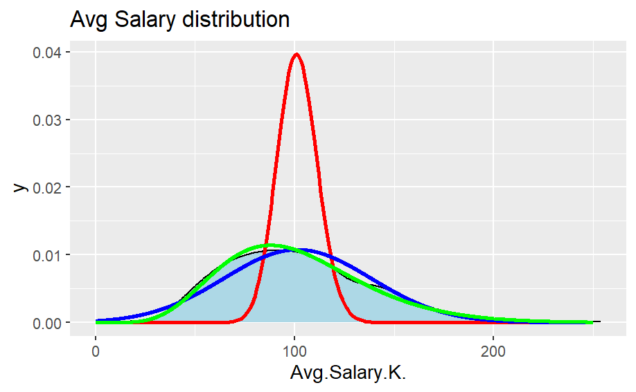

```r
lambda <- mean(Salary_data_Train$Avg.Salary.K.)
mean_val <- mean(Salary_data_Train$Avg.Salary.K.)
sd_val <- sd(Salary_data_Train$Avg.Salary.K.)

rate  = mean_val/var(Salary_data_Train$Avg.Salary.K.)
shape = rate * mean_val

xgrid = seq(0,250,0.1)

ggplot(Salary_data_Train, aes(Avg.Salary.K.)) +
  geom_density(fill = "lightblue") +
  geom_line(data = data.frame(x = 0:250, y = dpois(0:250, lambda = lambda)), aes(x = x, y = y), color = "red", size = 1) +
  geom_line(data = data.frame(x = xgrid, y = dnorm(xgrid, mean = mean_val, sd = sd_val)),
            aes(x = x, y = y), color = "blue", size = 1) +
  geom_line(data = data.frame(x = xgrid, y = dgamma(xgrid, shape = shape, rate = rate)),
            aes(x = x, y = y), color = "green", size = 1) +
  ggtitle("Avg Salary distribution")
```

As can be observed, the Gamma distribution is hte one that better fits our dataset, therefore, we would develop the GLM using it.

Futhermore, we can plot the objective variable in terms of other ones to find relations. For example, here we observe how the salary distribution differs a lot from one type of offer from another.

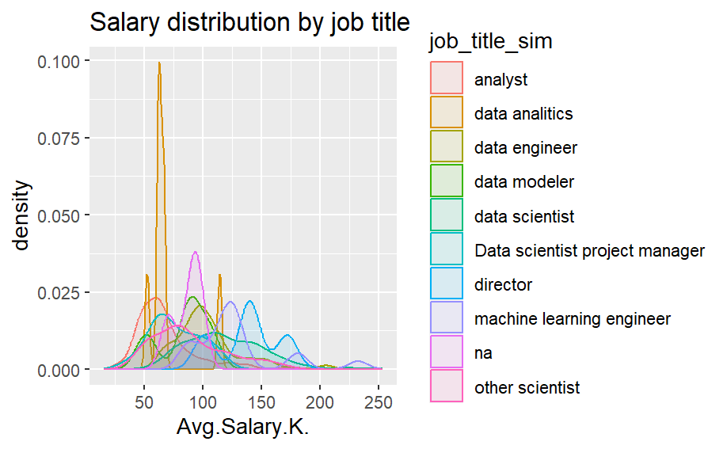

```r
ggplot(Salary_data_Train, aes(Avg.Salary.K.)) + geom_density(aes(group=job_title_sim, colour=job_title_sim, fill=job_title_sim), alpha=0.1) + ggtitle("Salary distribution by job title")
```

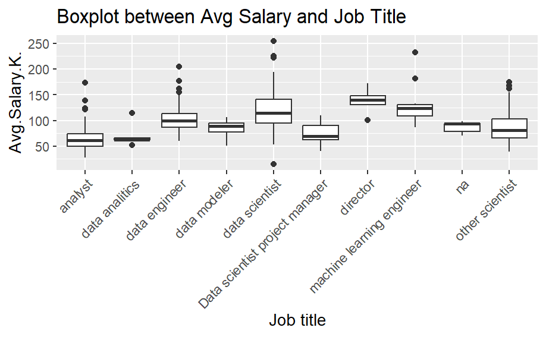

```r
ggplot(Salary_data_Train, aes(x = job_title_sim, y = Avg.Salary.K.)) +
  geom_boxplot() +
  labs(title = "Boxplot between Avg Salary and Job Title",
       x = "Job title",
       y = "Avg.Salary.K.")+
  theme(axis.text.x = element_text(angle = 45, hjust = 1))
```

Finally, we try to find some trend related with the rating of the companies and the mean salary, however, the scatter plot does not show any useful information.

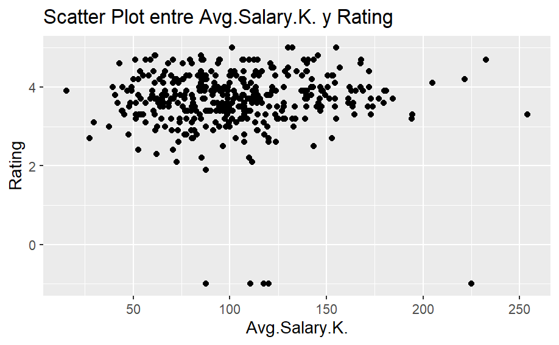

```r
ggplot(Salary_data_Train, aes(x = Avg.Salary.K., y = Rating)) +
  geom_point() +
  labs(title = "Scatter Plot entre Avg.Salary.K. y Rating",
       x = "Avg.Salary.K.",
       y = "Rating")
```

### Correlations

Before starting modeling the predictor, we try to find the numeric (and binary) variables more correlated with the objective feature.

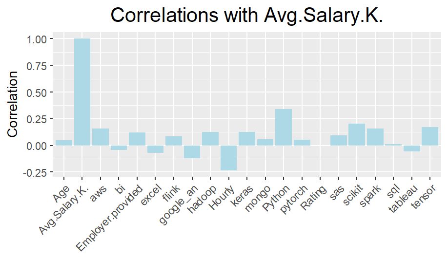

```r
# Calcular correlaciones
correlations <- cor(Salary_data_Train[, c("Age", "Rating", "Hourly", "Avg.Salary.K.", "Employer.provided", "Python", "spark", "aws", "excel", "sql", "sas", "keras", "pytorch", "scikit", "tensor", "hadoop", "tableau", "bi", "flink", "mongo", "google_an")])

# Extraer las correlaciones con la variable objetivo "Avg.Salary.K."
corr <- sort(correlations["Avg.Salary.K.",], decreasing = F)

# Crear un dataframe con las correlaciones
corr_df <- data.frame(variable = names(corr), correlation = corr)

# Crear el gráfico de barras
ggplot(corr_df, aes(x = variable, y = correlation)) +
  geom_bar(stat = "identity", fill = "lightblue") +
  labs(x = "", y = "Correlation", title = "Correlations with Avg.Salary.K.") +
  theme(plot.title = element_text(hjust = 0.5, size = rel(1.5)), axis.text.x = element_text(angle = 45, hjust = 1))
```

## Model development and interpretation

### Benchmark

```r
bench_glm = glm(Avg.Salary.K. ~ 1 , family = Gamma, data = Salary_data_Train)
#summary(bench_glm)

pred_bench_glm= predict(bench_glm, newdata= Salary_data_Test)

#Let's know validate the predictions, calculating R^2 in the testing set

# Evaluate performance on the test set
RMSE_test <- sqrt(mean((pred_bench_glm - Salary_data_Test$Avg.Salary.K.)^2))
cat("RMSE on test set:", RMSE_test, "\n")
```

```
RMSE on test set: 109.3489
```

### Developing the model

We would make a first approach, in order to evaluate the effects of each variable into the model. Later, we would try to choose the best variables to define the final model.

```r
## For controlling levels errors:
Salary_data_Test$Headquarters <- factor(Salary_data_Test$Headquarters, levels = levels(Salary_data_Train$Headquarters))

Salary_data_Test$company_txt <- factor(Salary_data_Test$company_txt, levels = levels(Salary_data_Train$company_txt))


## First glm
first_glm = glm(Avg.Salary.K. ~ job_title_sim+ Rating + Hourly + Employer.provided + Python + spark + aws + excel + sql + sas + keras + pytorch + scikit + tensor + hadoop + tableau + bi + flink + mongo + google_an + Size + Type.of.ownership + Sector + Revenue+ Job.Location + Age, family = Gamma, data = Salary_data_Train)
#summary(first_glm)

pred_f_glm= predict(first_glm, newdata= Salary_data_Test)

#Let's know validate the predictions, calculating R^2 in the testing set

# Evaluate performance on the test set
R2_test <- cor(pred_f_glm, Salary_data_Test$Avg.Salary.K.)^2
RMSE_test <- sqrt(mean((pred_f_glm - Salary_data_Test$Avg.Salary.K.)^2))

cat("R-squared on test set:", R2_test, "\n")
```

```
R-squared on test set: 0.3440595
```

```r
cat("RMSE on test set:", RMSE_test, "\n")
```

```
RMSE on test set: 109.3491
```

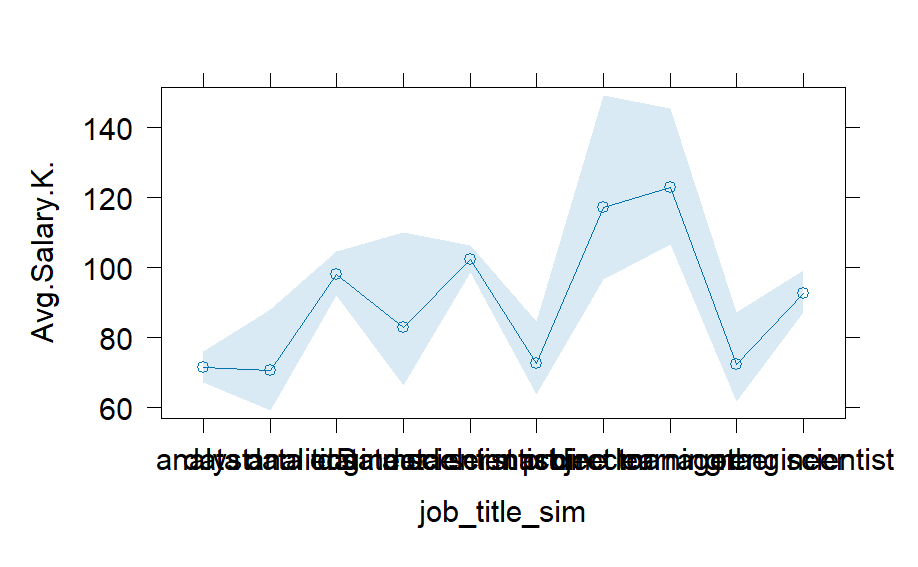

```r
library(effects)
variables = list("job_title_sim", "Rating", "Hourly", "Employer.provided" ,"Python" ,"spark", "aws" ,"excel", "sql" , "sas" , "keras" , "pytorch" , "scikit" ,"tensor" ,"hadoop" , "tableau" , "bi" , "flink" , "mongo" , "google_an", "Size", "Type.of.ownership",  "Sector",  "Revenue",  "Job.Location" , "Age")

plot(effect(variables[[1]], first_glm), ci.style="band", rescale.axis=FALSE, multiline=TRUE, ylab="Avg.Salary.K.", rug=FALSE, main="")
```

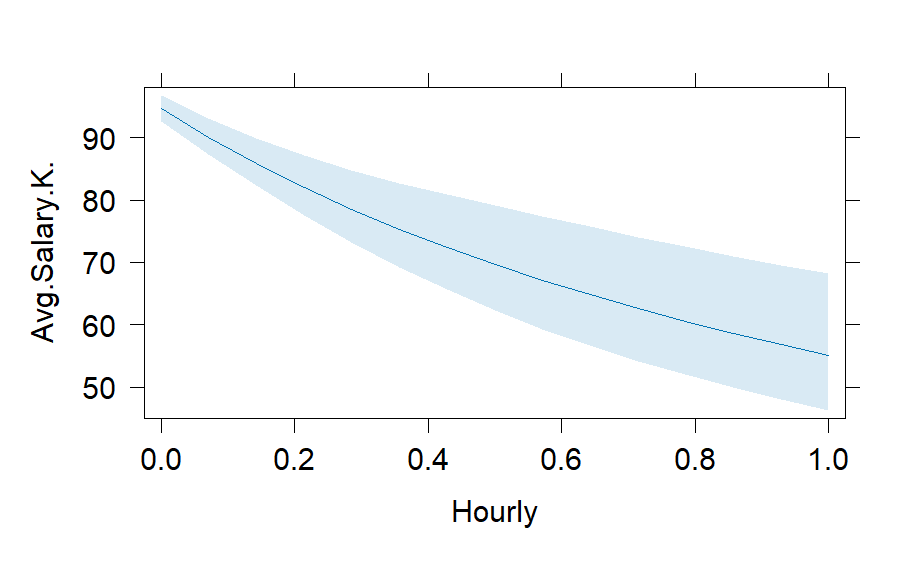

```r
plot(effect(variables[[3]], first_glm), ci.style="band", rescale.axis=FALSE, multiline=TRUE, ylab="Avg.Salary.K.", rug=FALSE, main="")
```

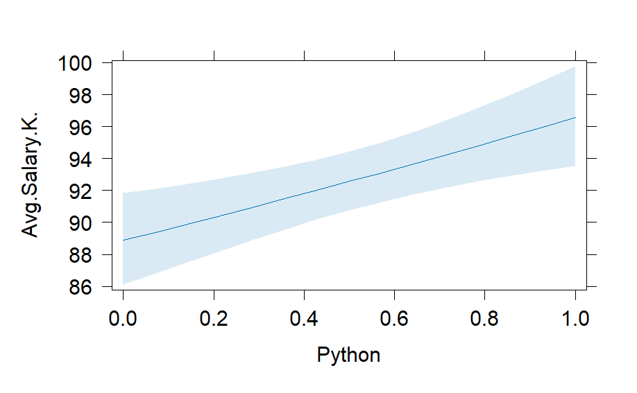

```r
plot(effect(variables[[5]], first_glm), ci.style="band", rescale.axis=FALSE, multiline=TRUE, ylab="Avg.Salary.K.", rug=FALSE, main="")
```

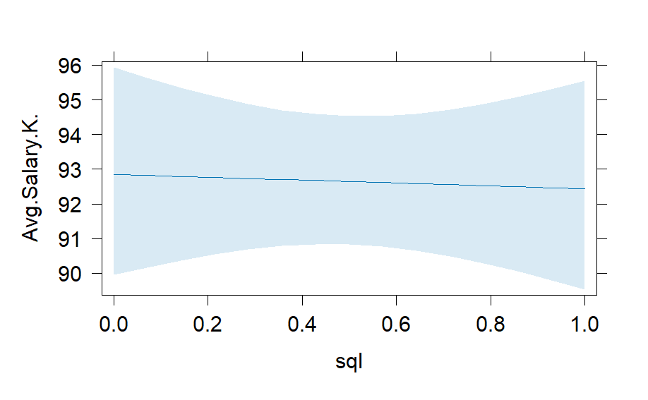

```r
plot(effect(variables[[9]], first_glm), ci.style="band", rescale.axis=FALSE, multiline=TRUE, ylab="Avg.Salary.K.", rug=FALSE, main="")
```

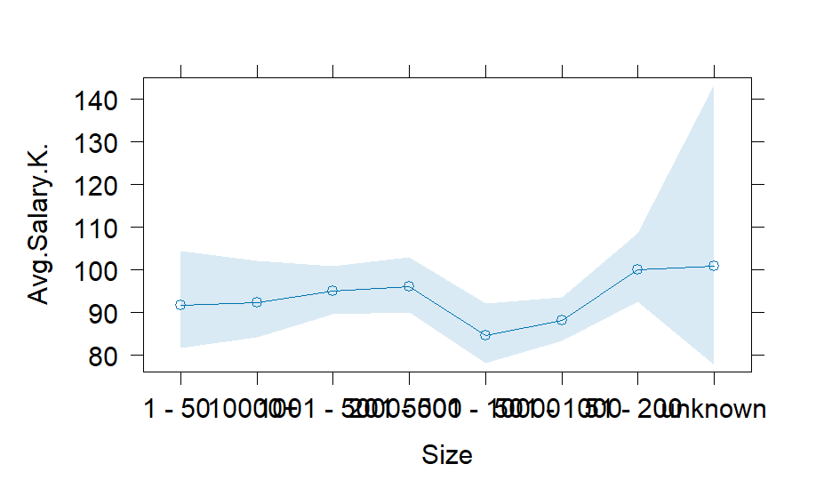

```r
plot(effect(variables[[21]], first_glm), ci.style="band", rescale.axis=FALSE, multiline=TRUE, ylab="Avg.Salary.K.", rug=FALSE, main="")
```